# Module 1 — Data and Quality Control

RNA-seq Tutorial: Six Wilms Tumors and Their Normal Kidneys, From TPM to a Trusted Matrix

Francesco Cecere** · *Senior Bioinformatic Researcher* · AORN Santobono-Pausilipon IRCCS

05 novembre 2026

# Welcome

This tutorial walks through a complete **bulk RNA-seq** analysis on a real pediatric cancer dataset, **Wilms tumor** (the most common kidney cancer of childhood), with **limma**, one of the most widely used and best-documented tools for differential expression.

| Module | Question |
| --- | --- |
| **1 — Data and quality control** (this one) | What is in the expression matrix, and do the samples look the way we expect? |
| **2 — Differential expression with limma** | Which genes change between each child’s tumor and their own normal kidney? |
| **3 — Gene set analysis** | Which biological programs do those changes point to? |

# Part 1 — The Dataset

The data come from **TARGET-WT**, the Wilms tumor project of the NCI’s **TARGET** program (the pediatric counterpart of the adult-focused TCGA), downloaded from the **GDC Data Portal**. TARGET-WT has RNA-seq for 124 tumors, but only **6 normal kidney** samples. We keep exactly those 6 children, each with **two samples: the tumor and the normal kidney next to it**.

All files are in `data/`, built by `data-prep/build_target_wt_data.R` and `data-prep/build_paired_subset.R`:

| File | What it is |
| --- | --- |
| `TARGET_WT_gene_expression_tpm.csv` | 19,938 protein-coding genes × **6 tumors**, in TPM |
| `TARGET_WT_control_gene_expression_tpm.csv` | the same genes × the **6 normal kidneys** of the same children |
| `sample_metadata.csv` | one row per tumor: age, sex, vital status |
| `TARGET_WT_control_clinical_raw.csv` | one row per normal sample, with the patient it comes from |

**Why a paired design?** Comparing a child’s tumor with **their own** normal kidney removes everything that differs between children: genetic background, age, sex, how the samples were collected. What is left is the tumor effect. Six pairs is a small experiment, which is exactly the situation where limma’s statistics (Module 2) make the biggest difference, and every step runs in seconds.

```r
tumor_tpm   <- read_csv("data/TARGET_WT_gene_expression_tpm.csv", show_col_types = FALSE)
control_tpm <- read_csv("data/TARGET_WT_control_gene_expression_tpm.csv", show_col_types = FALSE)

tumor_metadata   <- read_csv("data/sample_metadata.csv", show_col_types = FALSE)
control_metadata <- read_csv("data/TARGET_WT_control_clinical_raw.csv", show_col_types = FALSE)
```

## TPM: What the Numbers Mean

Each value is a **TPM** (*transcripts per million*). For gene $i$ with $X_i$ reads and effective length $\ell_i$ (kb):

$$\text{TPM}_i = \frac{X_i / \ell_i}{\sum_j X_j / \ell_j} \times 10^6$$

1. **Divide by gene length**: a long gene collects more reads than a short one at the same expression level.
2. **Divide by the sample’s total and multiply by one million**: removes the difference in sequencing depth between samples.

TPM values are already **normalized** and comparable across samples; summed over all genes, every sample totals exactly one million.

**TPM and the choice of method.** Count-based methods (DESeq2, edgeR, limma-*voom*) model the number of **reads**, and their statistics rely on the noise of counting. TPM no longer carries that information: the read counts have been divided by gene length and library size. For TPM, the appropriate approach is to work on **log2(TPM + 1)** with a method designed for continuous, approximately normal data. That is exactly what **limma** was built for (originally for microarrays), and Module 2 uses its **limma-trend** variant.

# Part 2 — Building One Matrix and One Sample Sheet

Tumors and normals arrive as two files. We combine them into **one matrix** (genes × samples) and **one sample sheet** in the same order. The sample sheet records, for every sample, its **condition** (Normal or Tumor) and its **patient**: the second column is what makes the design paired.

```r
# The two matrices must contain the same genes in the same order before being joined.
stopifnot(identical(tumor_tpm$gene_name, control_tpm$gene_name))

tpm <- as.matrix(bind_cols(tumor_tpm[, -1], control_tpm[, -1]))
rownames(tpm) <- tumor_tpm$gene_name

samples <- bind_rows(
  tumor_metadata %>% transmute(sample_id = case_submitter_id, patient = case_submitter_id,
                               condition = "Tumor", sex = sex_at_birth, age_years),
  control_metadata %>% transmute(sample_id = sample_submitter_id, patient = case_submitter_id,
                                 condition = "Normal")
) %>%
  group_by(patient) %>%
  fill(sex, age_years, .direction = "downup") %>%
  ungroup() %>%
  mutate(condition = factor(condition, levels = c("Normal", "Tumor")),
         patient   = factor(patient))

# The sample sheet must follow the matrix columns exactly: limma matches them by position.
samples <- samples[match(colnames(tpm), samples$sample_id), ]
stopifnot(identical(samples$sample_id, colnames(tpm)))

# Every patient must have exactly one tumor and one normal sample.
stopifnot(all(table(samples$patient, samples$condition) == 1))
```

The 12 samples: 6 children, each with a normal kidney and a tumor sample.

| patient | condition | sample_id | sex | age_years |
| --- | --- | --- | --- | --- |
| TARGET-50-CAAAAQ | Normal | TARGET-50-CAAAAQ-11A | female | 3.5 |
| TARGET-50-CAAAAQ | Tumor | TARGET-50-CAAAAQ | female | 3.5 |
| TARGET-50-CAAAAR | Normal | TARGET-50-CAAAAR-11A | female | 0.9 |
| TARGET-50-CAAAAR | Tumor | TARGET-50-CAAAAR | female | 0.9 |
| TARGET-50-PAJNRL | Normal | TARGET-50-PAJNRL-11A | male | 4.0 |
| TARGET-50-PAJNRL | Tumor | TARGET-50-PAJNRL | male | 4.0 |
| TARGET-50-PAJNSL | Normal | TARGET-50-PAJNSL-11A | female | 0.4 |
| TARGET-50-PAJNSL | Tumor | TARGET-50-PAJNSL | female | 0.4 |
| TARGET-50-PAJPHA | Normal | TARGET-50-PAJPHA-11A | male | 3.1 |
| TARGET-50-PAJPHA | Tumor | TARGET-50-PAJPHA | male | 3.1 |
| TARGET-50-PALKCW | Normal | TARGET-50-PALKCW-11A | male | 5.2 |
| TARGET-50-PALKCW | Tumor | TARGET-50-PALKCW | male | 5.2 |

**Reading the barcodes.** A tumor is named `TARGET-50-PALKCW`, its normal kidney `TARGET-50-PALKCW-11A`: same patient (`PALKCW`), sample type `11` = solid tissue normal. All six children have **Favorable** histology, the large majority of Wilms tumors.

# Part 3 — Sanity Checks

## TPM Totals

Our matrix keeps only **protein-coding** genes, so each sample sums to *somewhat less* than one million: the missing share is the sample’s non-coding RNA. A sample far off the rest has an unusual RNA composition.

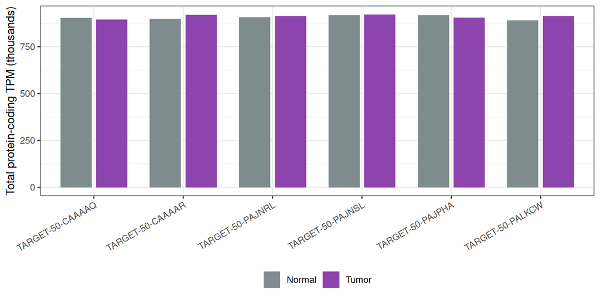

## Filtering Low-Expressed Genes

Genes that are essentially not expressed carry no information but still count as tests, making the multiple-testing correction harsher for every other gene. We keep a gene if it has **TPM ≥ 1 in at least 6 samples**, the size of one group, so a gene expressed only in normal kidney (or only in tumors) is still kept.

```r
min_samples <- min(table(samples$condition))
keep <- rowSums(tpm >= 1) >= min_samples

# log2(TPM + 1): the scale used from here on. The +1 avoids log(0).
log_expr <- log2(tpm[keep, ] + 1)
```

Effect of the expression filter.

| step | genes |
| --- | --- |
| Genes before | 19938 |
| Genes kept (TPM >= 1 in >= 6 samples) | 13599 |
| Genes removed | 6339 |

## Why the log Scale?

TPM values span six orders of magnitude, and their variance grows with their mean: a few very highly expressed genes would dominate any analysis on the raw scale. The log transform makes fold changes symmetric (doubling = +1, halving = −1) and the distribution much closer to the normal shape that linear models assume.

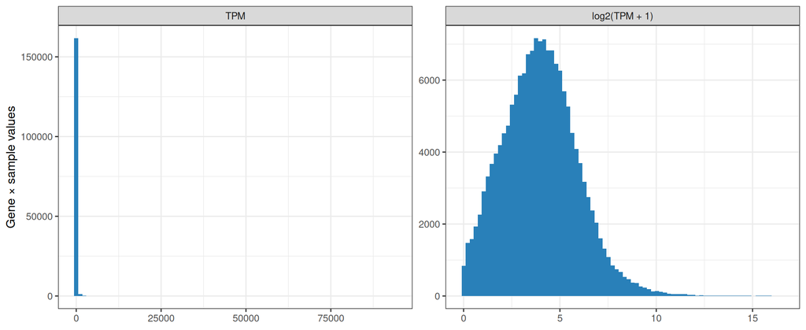

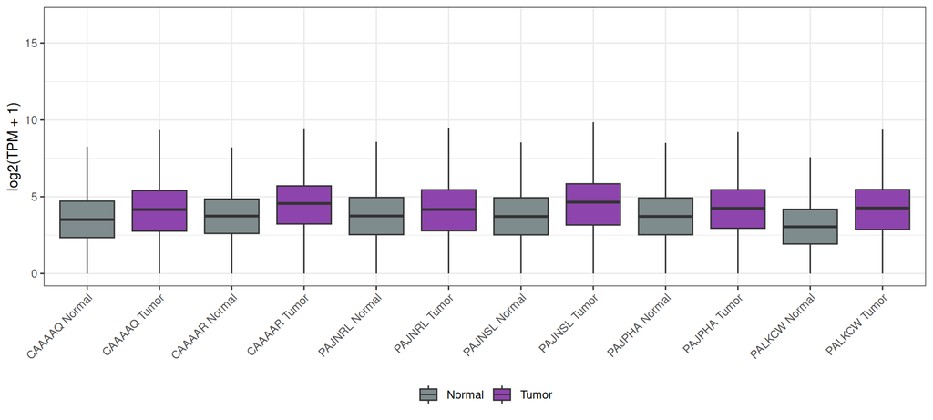

**What to look for.** One box per sample, with medians at roughly the same height: the normalization worked and no sample is grossly different.

# Part 4 — Principal Component Analysis

PCA summarizes thousands of genes into a few axes of variation; each sample becomes a point, and similar samples land close together. We use the **1,000 most variable genes**, centered but not scaled (all genes are already on the same log2 scale). A line joins the two samples of each child.

```r
top_variable <- names(sort(apply(log_expr, 1, var), decreasing = TRUE))[1:1000]
pca <- prcomp(t(log_expr[top_variable, ]), center = TRUE, scale. = FALSE)

percent_var <- round(100 * pca$sdev^2 / sum(pca$sdev^2), 1)
pca_scores  <- as_tibble(pca$x[, 1:4], rownames = "sample_id") %>% left_join(samples, by = "sample_id")
```

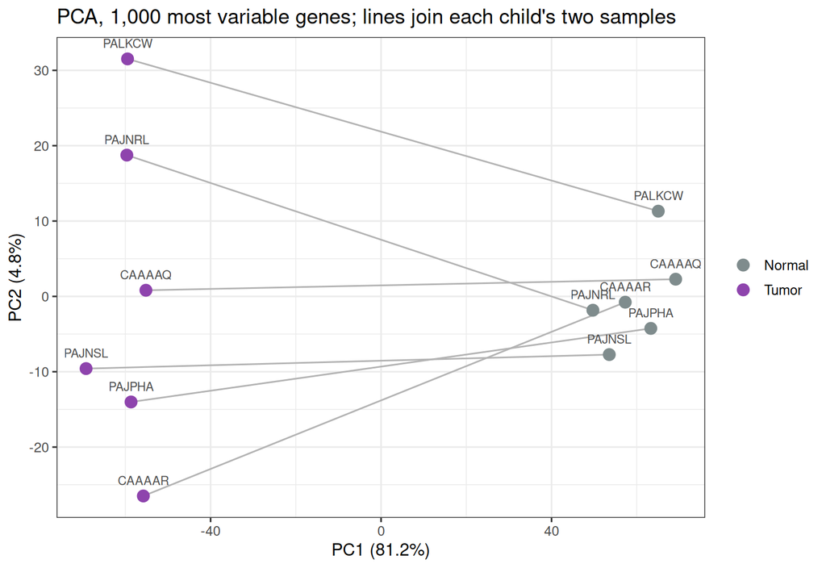

# Part 5 — Sample-Sample Correlation

For every pair of samples, the **Pearson correlation** of their log expression across all kept genes: 1 = identical profiles. The heatmap is clustered, so similar samples appear next to each other.

```r
sample_cor <- cor(log_expr, method = "pearson")
```

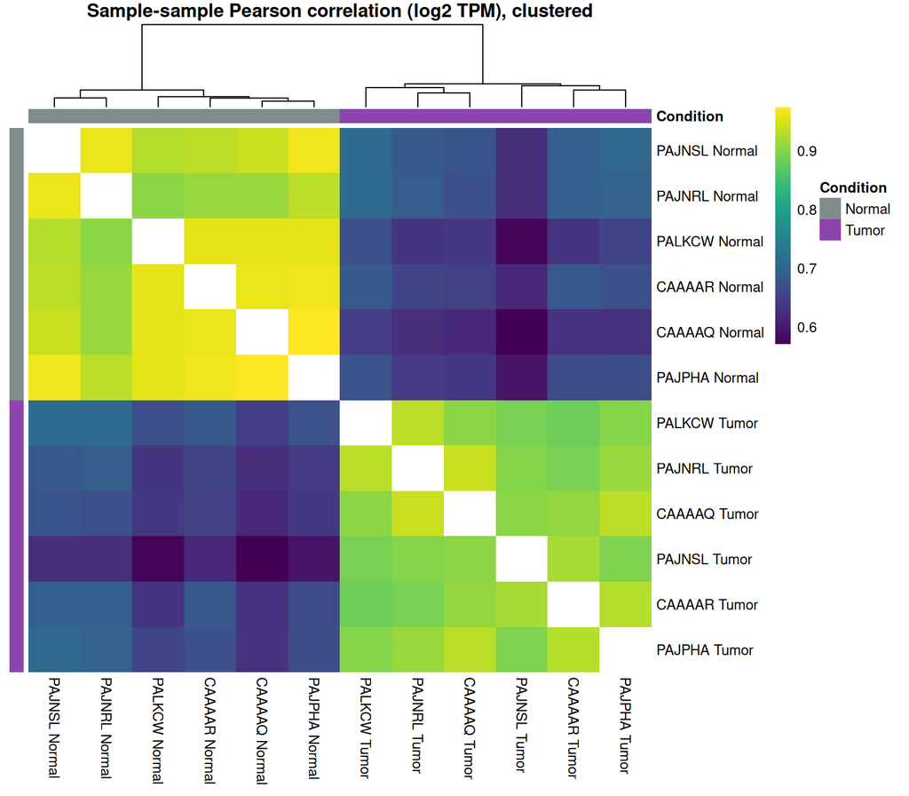

**Two blocks.** Normals correlate strongly with each other, tumors less so with each other, and normals with tumors least of all. A sample clustering with the wrong group, or correlating poorly with everything, would deserve a second look (RNA quality, tumor purity, a labeling error); none does here.

# Summary

- One matrix of 12 samples (6 tumors and their 6 normal kidneys) and one sample sheet, verified to match column by column.
- 13599 genes kept after filtering, analyzed as **log2(TPM + 1)**.
- Tumor vs normal kidney dominates the data, and is consistent across the six children.

Module 2 fits the limma model.

Generated on 05 novembre 2026 · Francesco Cecere (Senior Bioinformatic Researcher) · AORN Santobono-Pausilipon IRCCS